# Assignment 2

Damilare Olaleye

02-02-2020

#### Chapter 1 (continued)

#### Preview of Some R Data Structures

We are already familiar with vectors, scalars, character strings, and data frames. We’ll talk about some other objects such as …

- matrices (Chapter 3)
- lists (Chapter 4)
- factors and tables (Chapter 5)
- classes and generic structures (Chapter 9)

#### Introduction to Lists

A list is a container for values that can be of different types.

Example: Suppose you want to record for a particular student: (1) his age, (2) his name, (3) ages of his parents

Create a list with three components (a scalar, a character string, and a numerica vector):

```r
Joe <- list(age = 17, name = "Joe Smith",
            parent_ages = c(42, 38))
```

Say I want to extract Joe’s name (use $ sign):

```r
Joe$name
```

```
## [1] "Joe Smith"
```

#### Question 1

For your favorite professional sports team, construct a list `team` containing its `name`, the first `year` it was in existence, and a vector `wins` containing the number of wins for the last three seasons.

```r
sport_team <- list(name="Arsenal Fc", year=1886, wins= 571)
```

Display the `wins` for your team.

```r
sport_team$wins
```

```
## [1] 571
```

#### Example of a list: the `hist` function

Suppose you want to construct a histogram of some numeric data.

1. Have to choose breakpoints for the bins.
2. Compute the midpoints of the bins.
3. Count the number of observations in each bin.
4. Construct a graph of the counts using bars.

Here we construct a histogram of waiting times for Old Faithful – nothing is being stored.

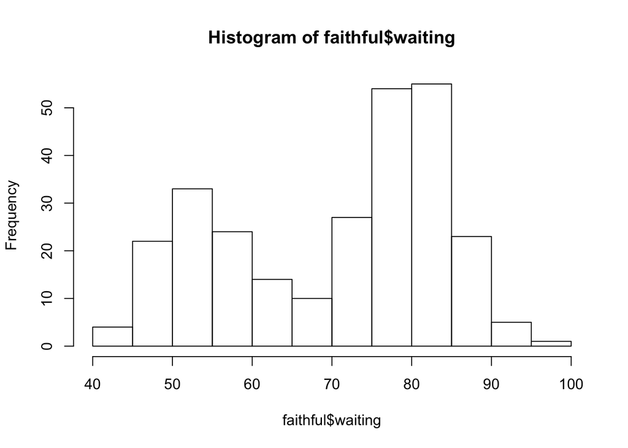

```r
hist(faithful$waiting)
```

Here we rerun this, setting `plot = FALSE` and storing the calculations in the list variable `h`.

```r
h <- hist(faithful$waiting, plot = FALSE)
h
```

```
## $breaks
##  [1]  40  45  50  55  60  65  70  75  80  85  90  95 100
##
## $counts
##  [1]  4 22 33 24 14 10 27 54 55 23  5  1
##
## $density
##  [1] 0.0029411765 0.0161764706 0.0242647059 0.0176470588 0.0102941176
##  [6] 0.0073529412 0.0198529412 0.0397058824 0.0404411765 0.0169117647
## [11] 0.0036764706 0.0007352941
##
## $mids
##  [1] 42.5 47.5 52.5 57.5 62.5 67.5 72.5 77.5 82.5 87.5 92.5 97.5
##
## $xname
## [1] "faithful$waiting"
##
## $equidist
## [1] TRUE
##
## attr(,"class")
## [1] "histogram"
```

#### Question 2

There are six components of the `hist` object. Write down the components and explain what each component means.

1.) density component: is the density of the cell. 2.) breaks component: the breaks component tells us where the bins in the histogram start and end. 3.) counts component: the counts component is the numbers of observations in each bin. 4.) mids component: is the midpoint of the cells. 5.) equidist component: is defined as the logical value indicating if the breaks are equally spaced or not. 6.) xname component: is defined as the argument name.

#### Question 3

Change the xname component of h to “Waiting Time”. Display the histogram by typing `plot(h)`. What has changed in this display?

Component xname changed to “Waiting Time”

Changed xname component of h to “Waiting Time” then Plot h here

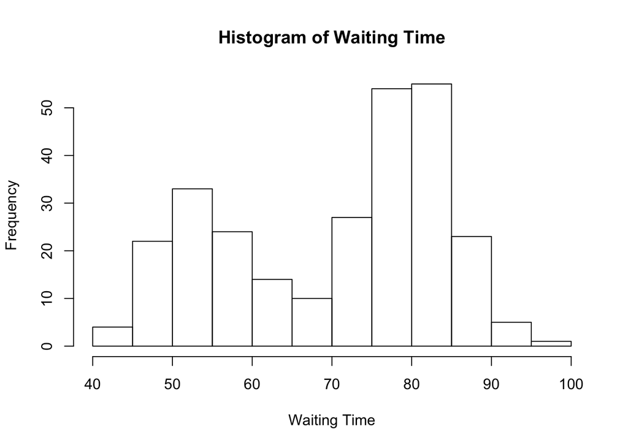

```r
h$xname <- "Waiting Time"
plot(h)
```

R is an object-oriented language and objects are instances of classes.

A `hist` function is associated with a “histogram” class.

Why do we have classes?

One reason is that they are used by generic functions like `summary`, `print`, and `plot`. We saw the use of the `plot` function above to construct the histogram.

`plot` has many meanings, depending on the class of the argument.